# Hockey sticks, rank dif, and clustering

```r
#source("~/Script repository/R scripting/My_Useful_Fns.R")#02/01/2022 commit at my github https://github.com/McK-Ford/Script-repository/blob/main/R%20scripting/My_Useful_Fns.R
library(tidyverse)
library(data.table)
DIR <- "C:/Users/kayle/Box/Vertinolab/GenomicSandbox/project_cell_lines/ProSeq/PEPPRO_SE/"
MB231_pI <- read.delim(
  paste0(DIR, "MB231/QC_hg38/MB231_pause_index.bed.gz"),
  header = FALSE,
  skipNul = TRUE
  )
MCF7_pI <- read.delim(
  paste0(DIR, "MCF7/QC_hg38/MCF7_pause_index.bed.gz"),
  header = FALSE,
  skipNul = TRUE
  )
MCF10A_pI <- read.delim(
  paste0(DIR, "MCF10A/QC_hg38/MCF10A_pause_index.bed.gz"),
  header = FALSE,
  skipNul = TRUE
  )
SUM159_pI <- read.delim(
  paste0(DIR, "SUM159/QC_hg38/SUM159_pause_index.bed.gz"),
  header = FALSE,
  skipNul = TRUE
  )
T47D_pI <- read.delim(
  paste0(DIR, "T47D/QC_hg38/T47D_pause_index.bed.gz"),
  header = FALSE,
  skipNul = TRUE
  )
```

skipNul - if do not provide this parameter, SUM and T47D fail with a ‘line 1 appears to contain embedded nullsWarning’. This appears to be some kind of encoding issue, but the data in R agrees with the data in excel once you add skipNul, so it’s not really worth messing with further.

Did we decide for sure what our filtering threshold would be? Talked with Paula. Greater than 95% confidence interval based on the log of the pI? 3 standard deviations is 99.7% of the data, given how few outliers we have on an arbitrary definition of such I’d prefer that. Or as we discussed with Paula, we could just do greater than 1K as threshold.

```r
tab_lst <- list(MB231 = MB231_pI,
               MCF10A = MCF10A_pI,
               MCF7 = MCF7_pI,
               SUM159 = SUM159_pI,
               T47D = T47D_pI)
for (i in seq_along(tab_lst)) {
  colnames(tab_lst[[i]]) = c("chrom", "start", "end", "symbol", "pI", "strand")
 # threshold = 10 ^ (mean(log10(tab_lst[[i]][[5]])) + (3 * sd(log10(tab_lst[[i]][[5]]))))
#  print(paste0("outlier cutoff is: ", threshold))
  tab_lst[[i]] = tab_lst[[i]] |>
    filter(tab_lst[[i]][[5]] < 1000)
 #   filter(tab_lst[[i]][[5]] <= threshold)
  print(
    paste0(
      "The number of genes for ",
      names(tab_lst)[[i]],
      " is: ",
      dim(tab_lst[[i]])[1]
      )
    )
    print(summary(tab_lst[[i]][[5]]))
    tab_lst[[i]]$cell_line = names(tab_lst)[[i]]

  }
```

```
[1] "The number of genes for MB231 is: 8637"
    Min.  1st Qu.   Median     Mean  3rd Qu.     Max.
  0.0221   4.0682   7.9418  12.5971  15.0644 372.5870
[1] "The number of genes for MCF10A is: 8527"
    Min.  1st Qu.   Median     Mean  3rd Qu.     Max.
  0.0119   4.6409  10.3738  19.2787  21.8874 916.6740
[1] "The number of genes for MCF7 is: 9759"
    Min.  1st Qu.   Median     Mean  3rd Qu.     Max.
  0.0041   4.2016   8.8849  14.9072  17.3761 567.8400
[1] "The number of genes for SUM159 is: 8142"
    Min.  1st Qu.   Median     Mean  3rd Qu.     Max.
  0.0119   4.5646   9.2085  15.1772  17.4802 599.2990
[1] "The number of genes for T47D is: 9023"
    Min.  1st Qu.   Median     Mean  3rd Qu.     Max.
  0.0031   3.6608   7.1012  10.7892  13.0224 933.1160
```

```r
pI_tab <- do.call(rbind, tab_lst)
```

Now I should be able to pivot that wider, though first of all filter

```r
pI_tab_wide <- pI_tab |>
  pivot_wider(id_cols = c("chrom", "start", "end", "symbol", "strand"),
              names_from = cell_line,
              names_prefix = "pI_",
              values_from = pI,
              values_fill = NA
              )
```

This indicates 24050 total genes have been identified. (How many are in more than one cell line? Not important at this point in the code where we’re treating these independently)

```r
setDT(pI_tab_wide)
pI_tab_wide[, ':='(pI_ro_T47D=frank(pI_T47D, na.last="keep"),
                             pI_ro_MB231=frank(pI_MB231, na.last="keep"),
                             pI_ro_SUM159=frank(pI_SUM159, na.last="keep"),
                             pI_ro_MCF7=frank(pI_MCF7, na.last="keep"),
                             pI_ro_MCF10A=frank(pI_MCF10A, na.last="keep"))]
```

```r
write.table(
  pI_tab,
  file = "peppro_pIs_w_rank.tsv",
  row.names = FALSE,
  sep = "\t",
  quote = FALSE
  )
```

```r
mytheme <- theme(
  panel.background=element_blank(),
  text=element_text(color="black",face="bold",family="sans"),
  axis.text=element_text(color="black"),
  axis.ticks=element_line(color="black"),
  plot.margin=unit(c(0.25, 0.25, .25, 0.25),"cm"),
  plot.title=element_text(vjust=2, hjust=0.5),
  panel.grid.major=element_blank(),
  panel.grid.minor=element_blank(),
  axis.title.y=element_text(vjust=0),
  axis.title.x=element_text(vjust=0),
  panel.border = element_blank(),
  axis.line=element_line()
)
```

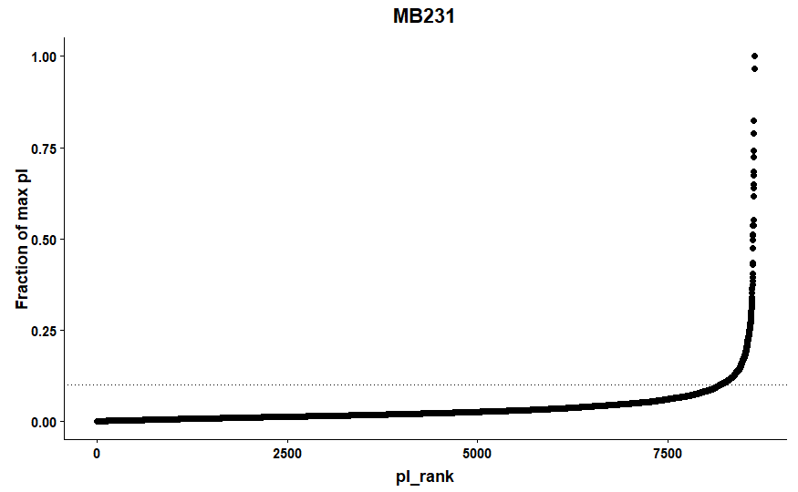

```r
MB231_hs <- ggplot(data=pI_tab_wide) +
  geom_point(aes(y=(pI_MB231/max(pI_MB231, na.rm=TRUE)), x=pI_ro_MB231)) +
  mytheme +
  xlab("pI_rank") +
  ylab("Fraction of max pI") +
  ggtitle("MB231")+
  geom_hline(aes(yintercept=0.1), linetype="dotted")
MB231_hs
```

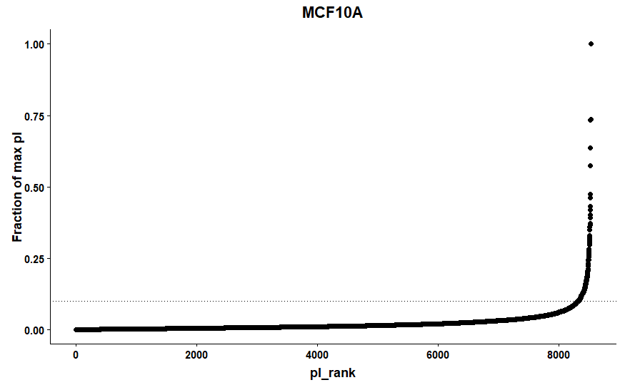

```r
MCF10A_hs <- ggplot(data=pI_tab_wide) +
  geom_point(aes(y=(pI_MCF10A/max(pI_MCF10A, na.rm=TRUE)), x=pI_ro_MCF10A)) +
  mytheme +
  xlab("pI_rank") +
  ylab("Fraction of max pI") +
  ggtitle("MCF10A")+
  geom_hline(aes(yintercept=0.1), linetype="dotted")
MCF10A_hs
```

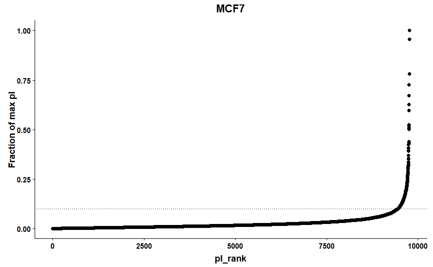

```r
MCF7_hs <- ggplot(data=pI_tab_wide) +
  geom_point(aes(y=(pI_MCF7/max(pI_MCF7, na.rm=TRUE)), x=pI_ro_MCF7)) +
  mytheme +
  xlab("pI_rank") +
  ylab("Fraction of max pI") +
  ggtitle("MCF7")+
  geom_hline(aes(yintercept=0.1), linetype="dotted")
MCF7_hs
```

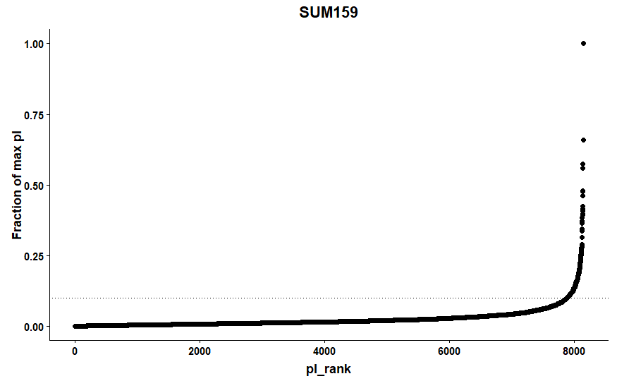

```r
SUM159_hs <- ggplot(data=pI_tab_wide) +
  geom_point(aes(y=(pI_SUM159/max(pI_SUM159, na.rm=TRUE)), x=pI_ro_SUM159)) +
  mytheme +
  xlab("pI_rank") +
  ylab("Fraction of max pI") +
  ggtitle("SUM159")+
  geom_hline(aes(yintercept=0.1), linetype="dotted")
SUM159_hs
```

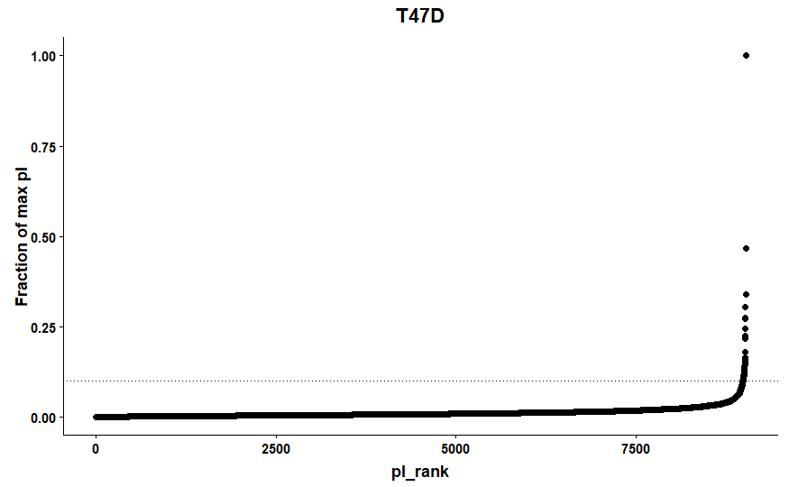

```r
T47D_hs <- ggplot(data=pI_tab_wide) +
  geom_point(aes(y=(pI_T47D/max(pI_T47D, na.rm=TRUE)), x=pI_ro_T47D)) +
  mytheme +
  xlab("pI_rank") +
  ylab("Fraction of max pI") +
  ggtitle("T47D")+
  geom_hline(aes(yintercept=0.1), linetype="dotted")
T47D_hs
```

```r
pdf(file = "project_cell_lines_hockey_sticks.pdf", width = 7)
T47D_hs
MB231_hs
```

```r
SUM159_hs
MCF7_hs
```

```r
MCF10A_hs
dev.off()
```

GSEA???

```r
top_90perc_SUM159 <- pI_tab_wide |>
  filter(pI_SUM159 >= 0.1 * (max(pI_SUM159, na.rm=TRUE)))
top_90perc_T47D <- pI_tab_wide |>
  filter(pI_T47D >=  0.1 * (max(pI_T47D, na.rm=TRUE)))
top_90perc_MB231 <- pI_tab_wide |>
  filter(pI_MB231 >=  0.1 * (max(pI_MB231, na.rm=TRUE)))
top_90perc_MCF7 <- pI_tab_wide |>
  filter(pI_MCF7 >=  0.1 * (max(pI_MCF7, na.rm=TRUE)))
top_90perc_MCF10A <- pI_tab_wide |>
  filter(pI_MCF10A >=  0.1 * (max(pI_MCF10A, na.rm=TRUE)))
dim(top_90perc_SUM159)
```

```
[1] 260  15
```

```r
dim(top_90perc_T47D)
```

```
[1] 40 15
```

```r
dim(top_90perc_MB231)
```

```
[1] 445  15
```

```r
dim(top_90perc_MCF7)
```

```
[1] 317  15
```

```r
dim(top_90perc_MCF10A)
```

```
[1] 206  15
```

```r
library(AnnotationDbi)
library(org.Hs.eg.db)
```

```r
library(enrichR)
```

```r
options(enrichR.base.address <- "https://amp.pharm.mssm.edu/Enrichr/")
```

```
$`https://amp.pharm.mssm.edu/Enrichr/`
NULL
```

```r
dbs <-listEnrichrDbs()
```

```r
dbs <- c("GO_Molecular_Function_2021", "GO_Biological_Process_2021", "KEGG_2021_Human")
MCF7_list <- top_90perc_MCF7[[4]]
MCF7_enriched <- enrichr(MCF7_list, dbs)
```

```
Uploading data to Enrichr... Done.
  Querying GO_Molecular_Function_2021... Done.
  Querying GO_Biological_Process_2021... Done.
  Querying KEGG_2021_Human... Done.
Parsing results... Done.
```

```r
SUM159_list <- top_90perc_SUM159[[4]]
SUM159_enriched <- enrichr(SUM159_list, dbs)
```

```
Uploading data to Enrichr... Done.
  Querying GO_Molecular_Function_2021... Done.
  Querying GO_Biological_Process_2021... Done.
  Querying KEGG_2021_Human... Done.
Parsing results... Done.
```

```r
T47D_list <- top_90perc_T47D[[4]]
T47D_enriched <- enrichr(T47D_list, dbs)
```

```
Uploading data to Enrichr... Done.
  Querying GO_Molecular_Function_2021... Done.
  Querying GO_Biological_Process_2021... Done.
  Querying KEGG_2021_Human... Done.
Parsing results... Done.
```

```r
MB231_list <- top_90perc_MB231[[4]]
MB231_enriched <- enrichr(MB231_list, dbs)
```

```
Uploading data to Enrichr... Done.
  Querying GO_Molecular_Function_2021... Done.
  Querying GO_Biological_Process_2021... Done.
  Querying KEGG_2021_Human... Done.
Parsing results... Done.
```

```r
MCF10A_list <- top_90perc_MCF10A[[4]]
MCF10A_enriched <- enrichr(MCF10A_list, dbs)
```

```
Uploading data to Enrichr... Done.
  Querying GO_Molecular_Function_2021... Done.
  Querying GO_Biological_Process_2021... Done.
  Querying KEGG_2021_Human... Done.
Parsing results... Done.
```

LoL = list of lists

```r
LoL <- list(MCF7_enriched, SUM159_enriched, T47D_enriched, MB231_enriched, MCF10A_enriched)
dbs <- as.list(dbs)
line_ids <- list("MCF7", "SUM159", "T47D", "MB231", "MCF10A")
for (i in seq_along(LoL)){
  tmp = Map(cbind, LoL[[i]], db_id=dbs)
  tmp2 = do.call(rbind, tmp)
  LoL[[i]] = tmp2
  }
LoL2 <- Map(cbind, LoL, line_id=line_ids)
enrichment_tab <- do.call(rbind, LoL2)
```

```r
enrichment_tab <- enrichment_tab |>
  dplyr::select(-c(5,6))
write.table(enrichment_tab, file="ontology.txt", quote=FALSE, sep="\t", row.names = FALSE)
```

```r
ont <- enrichment_tab |>
  separate(col=2, into=c("num_genes_match", "num_genes_set"),
           sep = "/", remove=TRUE, convert=TRUE)
```

```r
ont_GO_biol <- ont[ont$db_id == "GO_Biological_Process_2021",]
```

```r
ont_GO_biol <- ont_GO_biol |>
    group_by(line_id) |>
    slice_min(P.value, n=10) |>
    ungroup()
```

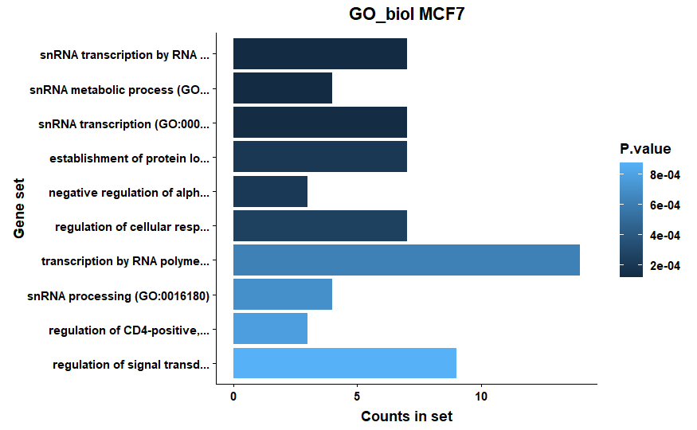

```r
#to make the p value scales better:
ont_GO_biol_MCF7 <- ggplot(data = ont_GO_biol[ont_GO_biol$line_id == "MCF7",]) +
  geom_col(
    aes(y = reorder(Term, P.value, decreasing = TRUE),
        x = num_genes_match, fill = P.value)
    ) +
  mytheme +
  xlab("Counts in set") +
  ylab("Gene set") +
  ggtitle("GO_biol MCF7") +
  scale_y_discrete(labels = function(x) stringr::str_trunc(x, 30))
ont_GO_biol_MCF10A <- ggplot(data=ont_GO_biol[ont_GO_biol$line_id=="MCF10A",]) +
  geom_col(aes(y=reorder(Term, P.value, decreasing=TRUE), x=num_genes_match, fill=P.value)) +
  mytheme +
  xlab("Counts in set") +
  ylab("Gene set") +
  ggtitle("GO_biol MCF10A") +
  scale_y_discrete(labels = function(x) stringr::str_trunc(x, 30))
ont_GO_biol_MB231 <- ggplot(data=ont_GO_biol[ont_GO_biol$line_id=="MB231",]) +
  geom_col(aes(y=reorder(Term, P.value, decreasing=TRUE), x=num_genes_match, fill=P.value)) +
  mytheme +
  xlab("Counts in set") +
  ylab("Gene set") +
  ggtitle("GO_biol MB231") +
  scale_y_discrete(labels = function(x) stringr::str_trunc(x, 30))
ont_GO_biol_SUM159 <- ggplot(data=ont_GO_biol[ont_GO_biol$line_id=="SUM159",]) +
  geom_col(aes(y=reorder(Term, P.value, decreasing=TRUE), x=num_genes_match, fill=P.value)) +
  mytheme +
  xlab("Counts in set") +
  ylab("Gene set") +
  ggtitle("GO_biol SUM159") +
  scale_y_discrete(labels = function(x) stringr::str_trunc(x, 30))
ont_GO_biol_T47D <- ggplot(data=ont_GO_biol[ont_GO_biol$line_id=="T47D",]) +
  geom_col(aes(y=reorder(Term, P.value, decreasing=TRUE), x=num_genes_match, fill=P.value)) +
  mytheme +
  xlab("Counts in set") +
  ylab("Gene set") +
  ggtitle("GO_biol T47D") +
  scale_y_discrete(labels = function(x) stringr::str_trunc(x, 30))
ont_GO_biol_MCF7
```

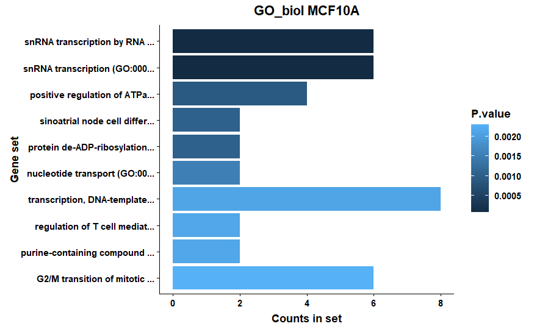

```r
ont_GO_biol_MCF10A
```

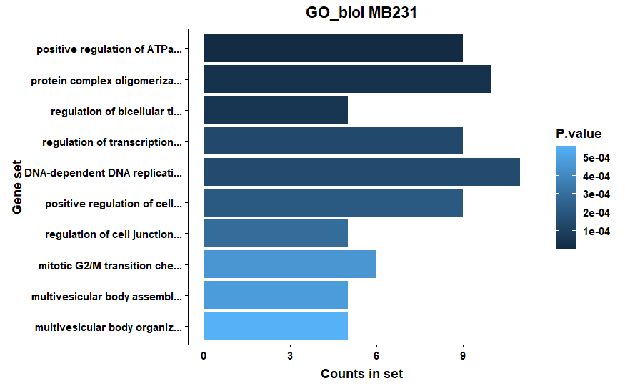

```r
ont_GO_biol_MB231
```

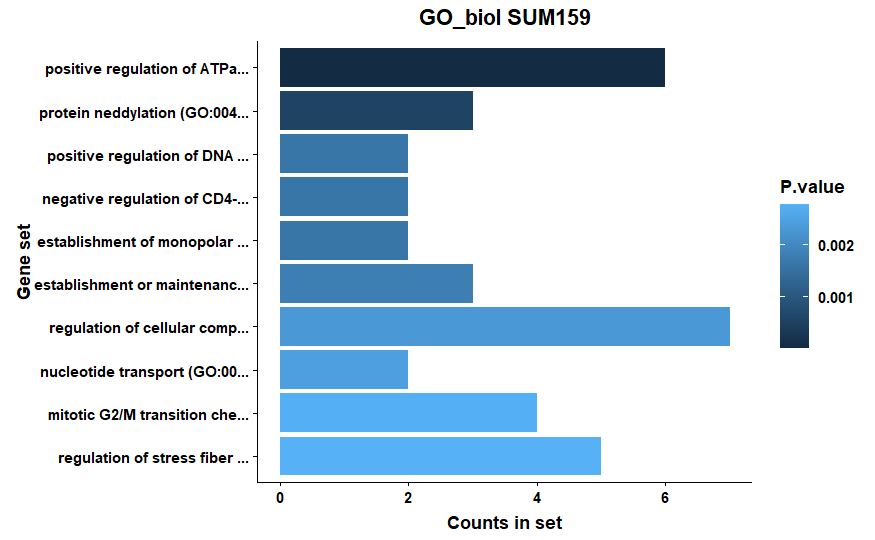

```r
ont_GO_biol_SUM159
```

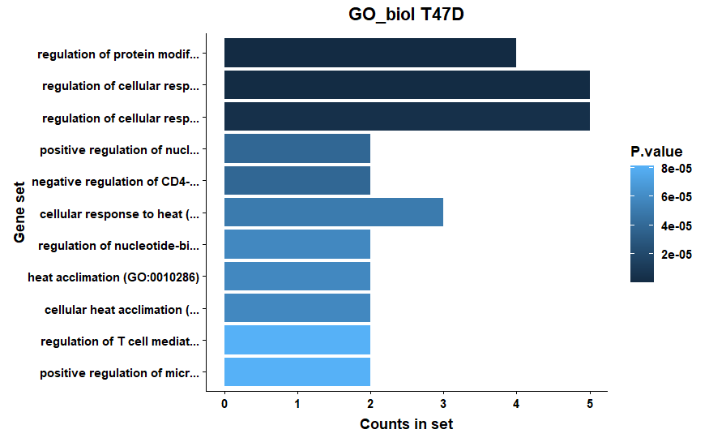

```r
ont_GO_biol_T47D
```

```r
pdf(file="project_cell_lines_ontology.pdf", width = 15)
ont_GO_biol_MCF7
ont_GO_biol_MCF10A
```

```r
ont_GO_biol_MB231
ont_GO_biol_SUM159
```

```r
ont_GO_biol_T47D
dev.off()
```

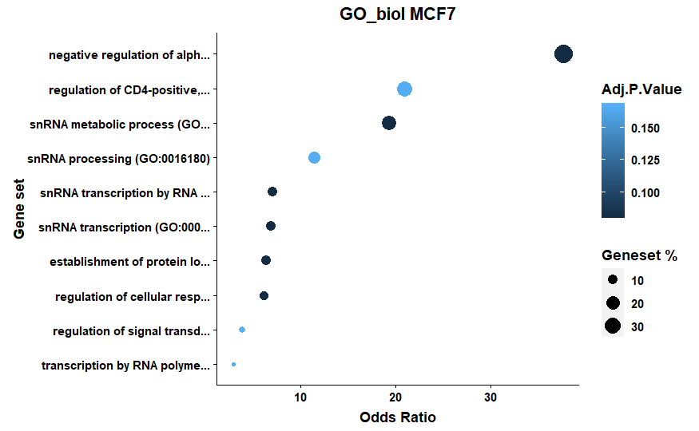

```r
circle_plot_MCF7 <- ggplot(data=ont_GO_biol[ont_GO_biol$line_id=="MCF7",]) +
  geom_point(aes(y=reorder(Term, Odds.Ratio),
                 x=Odds.Ratio, color=Adjusted.P.value,
                 size=(num_genes_match/num_genes_set*100))) +
  mytheme +
  xlab("Odds Ratio") +
  ylab("Gene set") +
  ggtitle("GO_biol MCF7") +
  scale_y_discrete(labels = function(x) stringr::str_trunc(x, 30)) +
  scale_color_continuous(name="Adj.P.Value") +
  scale_size_continuous(name="Geneset %")
circle_plot_MCF10A <- ggplot(data=ont_GO_biol[ont_GO_biol$line_id=="MCF10A",]) +
  geom_point(aes(y=reorder(Term, Odds.Ratio),
                 x=Odds.Ratio, color=Adjusted.P.value,
                 size=(num_genes_match/num_genes_set*100))) +
  mytheme +
  xlab("Odds Ratio") +
  ylab("Gene set") +
  ggtitle("GO_biol MCF10A") +
  scale_y_discrete(labels = function(x) stringr::str_trunc(x, 30)) +
  scale_color_continuous(name="Adj.P.Value") +
  scale_size_continuous(name="Geneset %")
circle_plot_MB231 <- ggplot(data=ont_GO_biol[ont_GO_biol$line_id=="MB231",]) +
  geom_point(aes(y=reorder(Term, Odds.Ratio),
                 x=Odds.Ratio, color=Adjusted.P.value,
                 size=(num_genes_match/num_genes_set*100))) +
  mytheme +
  xlab("Odds Ratio") +
  ylab("Gene set") +
  ggtitle("GO_biol MB231") +
  scale_y_discrete(labels = function(x) stringr::str_trunc(x, 30)) +
  scale_color_continuous(name="Adj.P.Value") +
  scale_size_continuous(name="Geneset %")
circle_plot_SUM159 <- ggplot(data=ont_GO_biol[ont_GO_biol$line_id=="SUM159",]) +
  geom_point(aes(y=reorder(Term, Odds.Ratio),
                 x=Odds.Ratio, color=Adjusted.P.value,
                 size=(num_genes_match/num_genes_set*100))) +
  mytheme +
  xlab("Odds Ratio") +
  ylab("Gene set") +
  ggtitle("GO_biol SUM159") +
  scale_y_discrete(labels = function(x) stringr::str_trunc(x, 30)) +
  scale_color_continuous(name="Adj.P.Value") +
  scale_size_continuous(name="Geneset %")
circle_plot_T47D <- ggplot(data=ont_GO_biol[ont_GO_biol$line_id=="T47D",]) +
  geom_point(aes(y=reorder(Term, Odds.Ratio),
                 x=Odds.Ratio, color=Adjusted.P.value,
                 size=(num_genes_match/num_genes_set*100))) +
  mytheme +
  xlab("Odds Ratio") +
  ylab("Gene set") +
  ggtitle("GO_biol T47D") +
  scale_y_discrete(labels = function(x) stringr::str_trunc(x, 30)) +
  scale_color_continuous(name="Adj.P.Value") +
  scale_size_continuous(name="Geneset %")
circle_plot_MCF7
```

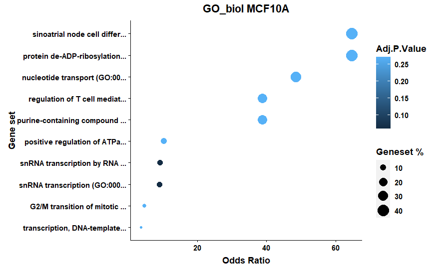

```r
circle_plot_MCF10A
```

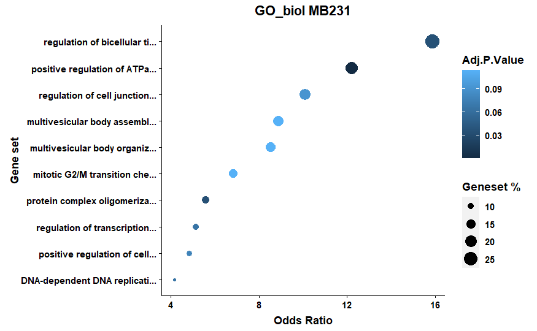

```r
circle_plot_MB231
```

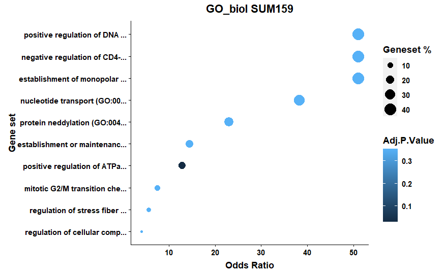

```r
circle_plot_SUM159
```

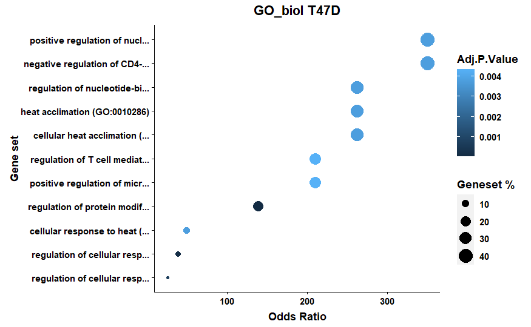

```r
circle_plot_T47D
```

```r
pdf(file="project_cell_lines_circleplot_ontology.pdf", width = 15)
circle_plot_MCF7
circle_plot_MCF10A
```

```r
circle_plot_MB231
circle_plot_SUM159
```

```r
circle_plot_T47D
dev.off()
```

Alright, let’s grab rankdif.

```r
pI_tab_wide$rankdif_MCF7vsSUM <- pI_tab_wide$pI_ro_MCF7 - pI_tab_wide$pI_ro_SUM159
pI_tab_wide$rankdif_T47DvsMB231 <- pI_tab_wide$pI_ro_T47D - pI_tab_wide$pI_ro_MB231
```

```r
pI_tab_wide$absrankdif_MCF7vsSUM <- abs(pI_tab_wide$rankdif_MCF7vsSUM)
pI_tab_wide$absrankdif_T47DvsMB231 <- abs(pI_tab_wide$rankdif_T47DvsMB231)
```

```r
write.table(pI_tab_wide, file="project_cell_lines_pI_withrankdif.txt", quote=FALSE, sep="\t", row.names = FALSE)
```

Now for clustering

```r
pI_tab_simple <- pI_tab_wide |>
  filter(!grepl('chrY|chrX', chrom))
```

```r
pI_tab_simple_log10 <- cbind(
  pI_tab_simple[,1:5], log10(as.matrix(pI_tab_simple[,6:10]))
  )
```

Don’t need ranks or anything for this one.

```r
pI_simple_log10 <- pI_tab_simple_log10 |>
  rowwise() |>
  mutate(stdev = sd(c(pI_MCF7, pI_SUM159, pI_MCF10A, pI_T47D, pI_MB231),
                    na.rm=TRUE),
         meanpi = mean(c(pI_MCF7, pI_SUM159, pI_MCF10A, pI_T47D, pI_MB231),
                       na.rm = TRUE),
         pivar = var(c(pI_MCF7, pI_SUM159, pI_MCF10A, pI_T47D, pI_MB231),
                     na.rm = TRUE)) |>
  ungroup()
```

(Need ungroup, otherwise is rowwise df and causes problems later) Remove genes with NA:

```r
pI_no_na = pI_simple_log10 %>%
            filter(!is.na(pI_MCF7) &
                     !is.na(pI_SUM159) &
                     !is.na(pI_MCF10A) &
                     !is.na(pI_T47D) &
                     !is.na(pI_MB231)                   )
```

Only 1276 genes??? Did not expect that honestly…Let’s just cluster with all of them then??? Can always venn diagram too?

```r
pI_norm <- pI_no_na |>
  rowwise() |>
  mutate(MB231norm = (pI_MB231 - meanpi) / stdev,
        MCF10Anorm = (pI_MCF10A - meanpi) / stdev,
        MCF7norm = (pI_MCF7 - meanpi) / stdev,
         SUM159norm = (pI_SUM159 - meanpi) / stdev,
         T47Dnorm = (pI_T47D - meanpi) / stdev) |>
  ungroup()
```

Normalized matrix:

```r
simple_mat = as.matrix(pI_norm[,14:18])
rownames(simple_mat) = pI_norm[[4]]
colnames(simple_mat) = c("MB231", "MCF10A", "MCF7", "SUM159", "T47D")
```

Not normalized matrix:

```r
simple_mat_nn = as.matrix(pI_norm[,6:10])
rownames(simple_mat) = pI_norm[[4]]
colnames(simple_mat) = c("MB231", "MCF10A", "MCF7", "SUM159", "T47D")
```

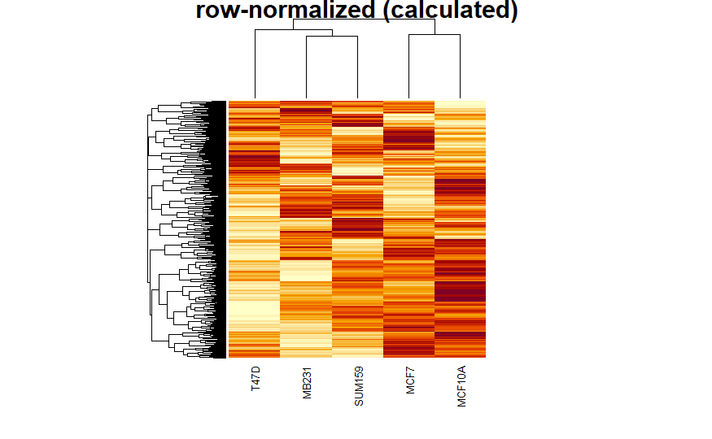

```r
heatmap(simple_mat, scale="none", cexCol = 0.8, labRow = "", main = "row-normalized (calculated)", na.rm = TRUE)
```

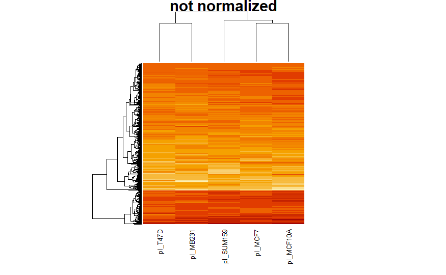

```r
heatmap(simple_mat_nn, scale="none", cexCol = 0.8, labRow = "", main = "not normalized", na.rm = TRUE)
```

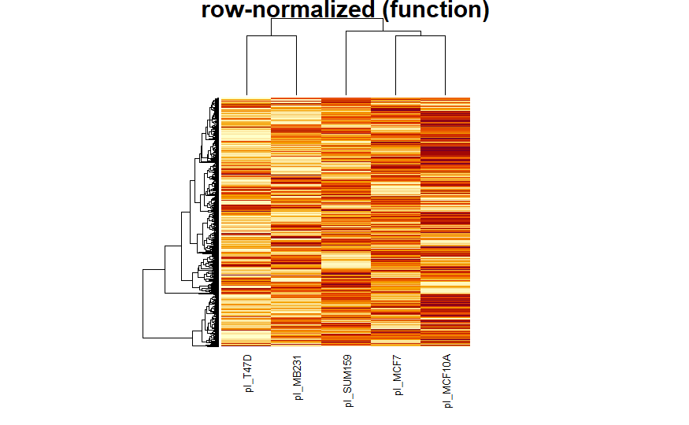

```r
heatmap(simple_mat_nn, scale="row", cexCol = 0.8, labRow = "", main = "row-normalized (function)", na.rm = TRUE)
```

The third one is technically the one Paula wanted, so:

```r
hm = heatmap(simple_mat_nn, scale="row", cexCol = 0.8, labRow = "", main = "pI clustering (n=1276)", na.rm = TRUE)
pdf(file = "cluster.pdf", width = 15)
```

```r
hm
```

[output not shown]

[output cut: 44 more lines]

[figure not shown]

```r
dev.off()
```

Over 24K genes, only 1.2K share a pause. Why??? Venn diagram time…Probably easiest with a set of true_false bool columns

```r
pI_tab_simple$MB231_tf = !is.na(pI_tab_simple$pI_MB231)
```

Works great, do for rest.

```r
pI_tab_simple$MCF10A_tf <- !is.na(pI_tab_simple$pI_MCF10A)
pI_tab_simple$MCF7_tf <- !is.na(pI_tab_simple$pI_MCF7)
pI_tab_simple$SUM159_tf <- !is.na(pI_tab_simple$pI_SUM159)
pI_tab_simple$T47D_tf <- !is.na(pI_tab_simple$pI_T47D)
```

```r
install.packages("venn")
```

```r
library(venn)
```

```r
tf_mat = pI_tab_simple[,20:24]
colnames(tf_mat) = c("MB231", "MCF10A", "MCF7", "SUM159", "T47D")
```

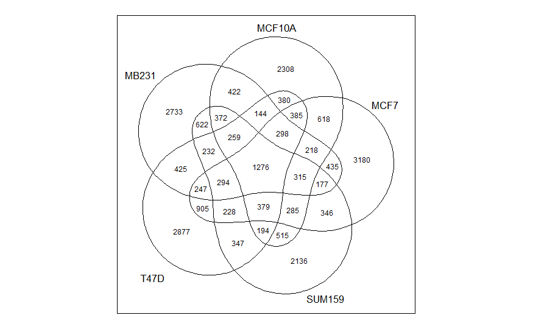

```r
venn(tf_mat)
```

Nice! Refine it…

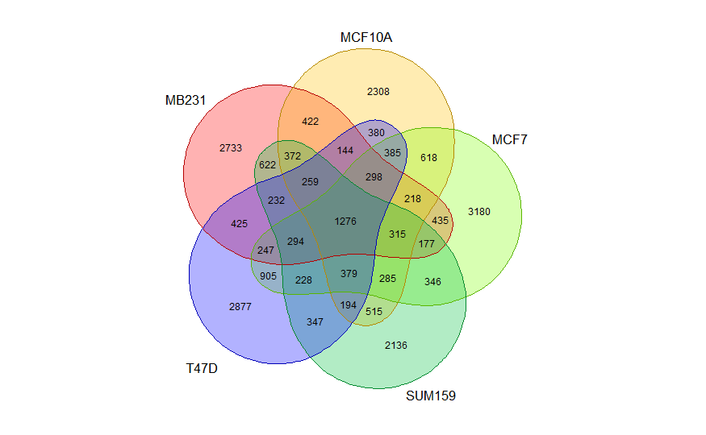

```r
pI_venn = venn(tf_mat, zcolor = "style", box = FALSE)
```

```r
pdf(file = "venn.pdf", width = 15)
pI_venn
```

```r
dev.off()
```